← Niger drought AA

# Niger 2026 Jun–Jul rainfall vs the observational trigger

**Question:** how likely is the observational arm of the Niger drought trigger to fire this year? The arm uses the **ENACTS MON Jun–Jul SPI** published on the IRI Maproom, which is not yet available to us for 2026. As a stopgap, this page evaluates 2026 Jun–Jul rainfall over the monitored zone (**Niger south of 17°N**) in two independent datasets we *do* have — **ERA5** reanalysis and **CHIRPS v2.0** — and asks where 2026 falls in each dataset's own historical record, relative to the current candidate threshold (**driest 15 % of years**, full record, value-locked).

⚠️ This is a proxy analysis. The trigger decision is made on the ENACTS SPI from the Maproom, not on either of these datasets.

## 2026 Jun–Jul rainfall over the monitored zone

Left: total Jun–Jul precipitation. Right: the same total as a percentage of the 1991–2020 Jun–Jul climatology. The monitored zone (Niger south of 17°N, black outline) is the spatial mean used everywhere below; the dashed line is 17°N.

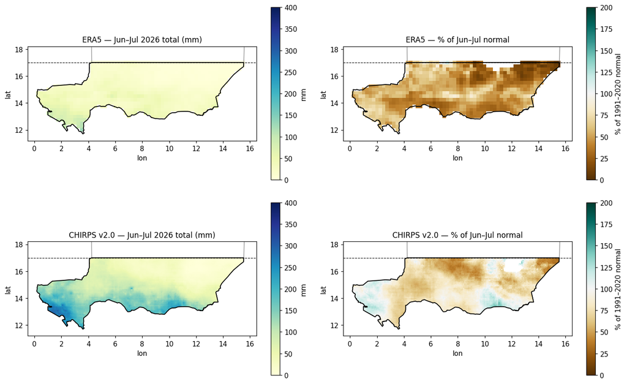

## Historical record and where 2026 falls

Zonal-mean Jun–Jul rainfall by year. The red line is the **15 %** value-locked threshold over the 1991–2025 record; the lighter orange line is the endorsed PDF's **35 %** alternative. Years at or below the 15 % threshold are circled.

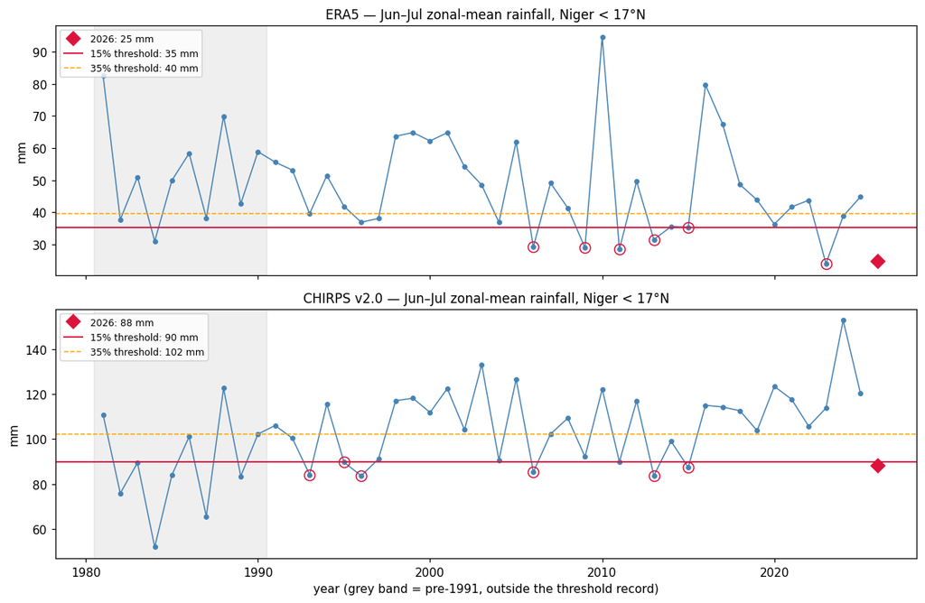

### 2026 vs the threshold — summary

| Source | 2026 Jun–Jul (mm) | Record median (mm) | Dry rank of 2026 | Empirical percentile | RP of 2026 dryness | 15% threshold (mm) | Margin vs 15% (mm) | Triggers at 15%? | Triggers at 35%? |
| --- | --- | --- | --- | --- | --- | --- | --- | --- | --- |
| ERA5 | 25 | 44 | 2 of 36 | 5% | 18.5 yr | 35 | -11 | YES | YES |
| CHIRPS v2.0 | 88 | 109 | 6 of 36 | 16% | 6.2 yr | 90 | -2 | YES | YES |

Dry rank counts 2026 within the 1991–2025 record plus 2026 itself (1 = driest). The return period is the Weibull plotting position (n+1)/rank of the 2026 value; percentile = rank/(n+1). A positive margin means 2026 is wetter than the threshold (no trigger).

### Sensitivity: would 2026 trigger at other percentile choices?

| Percentile | ERA5 threshold (mm) | ERA5 2026 triggers? | CHIRPS v2.0 threshold (mm) | CHIRPS v2.0 2026 triggers? |
| --- | --- | --- | --- | --- |
| 5% | 28 | YES | 84 | no |
| 10% | 29 | YES | 85 | no |
| 15% | 35 | YES | 90 | YES |
| 20% | 36 | YES | 90 | YES |
| 25% | 37 | YES | 91 | YES |
| 30% | 38 | YES | 99 | YES |
| 35% | 40 | YES | 102 | YES |
| 40% | 41 | YES | 104 | YES |

## Cross-check against the actual trigger indicator

The trigger's observational indicator is the Maproom Jun–Jul SPI (the "Aug" column of the trigger dataset, 1991–2025). If ERA5 or CHIRPS is to stand in for it, they should co-vary with it. The scatter below shows each proxy against the Maproom SPI over the common record, with a least-squares fit used to translate the 2026 proxy value into an implied 2026 SPI.

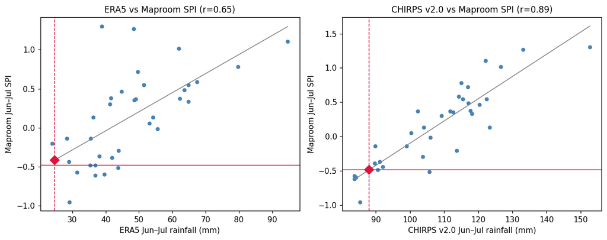

| Source | Pearson r | Spearman ρ | Implied 2026 SPI | SPI 15% threshold | Implied trigger? |
| --- | --- | --- | --- | --- | --- |
| ERA5 | 0.65 | 0.67 | -0.416 | -0.484 | no |
| CHIRPS v2.0 | 0.89 | 0.88 | -0.483 | -0.484 | no |

Red solid line: the 15 % value-locked threshold on the SPI record itself; red dashed line and diamond: the 2026 proxy value and its implied SPI. The implied SPI is a linear translation and carries the fit's uncertainty — treat it as indicative only.

## Bottom line

- **ERA5**: 2026 is the 2nd driest of 36 years (≈5th percentile, 1-in-18.5-yr dryness), 11 mm below the 15% threshold → **would trigger**. Implied Maproom SPI ≈ -0.416 (threshold -0.484).
- **CHIRPS v2.0**: 2026 is the 6th driest of 36 years (≈16th percentile, 1-in-6.2-yr dryness), 2 mm below the 15% threshold → **would trigger**. Implied Maproom SPI ≈ -0.483 (threshold -0.484).

Both proxies put 2026 at or below the 15 % rainfall threshold, but CHIRPS — much the better-correlated proxy — sits *exactly at the line*: 6th driest of 36 (the threshold rank), and its implied SPI lands within a few thousandths of the SPI threshold. Read this as a **coin-flip-or-better chance** that the ENACTS value triggers at 15 %, and a near-certain trigger if the endorsed 35 % threshold is used instead.

## Methodology & caveats

- **Zone:** Niger admin-0 (FieldMaps CODAB) clipped to south of 17°N — the monitored zone of the Niger drought AA framework. Statistic: unweighted pixel mean over the zone.
- **ERA5:** monthly total-precipitation COGs from the team raster pipeline (prod blob, `era5/monthly/processed/`), mm/day × days-in-month. 1981–2026.
- **CHIRPS v2.0:** Africa monthly GeoTIFFs from the Climate Hazards Center (final product, mm/month). 1981–2026.
- **Threshold convention:** value-locked, as in the trigger explorer — the *k*-th driest observed year where *k = ceil(p/100 × n)* over the 1991–2025 record (n = 35; p = 15 % → k = 6). Pre-1991 years are shown for context but excluded from thresholds, matching the framework's "driest years since 1991" baseline.
- **Return period:** Weibull plotting position — RP = (n + 1)/rank of the 2026 value among 1991–2025 + 2026.
- **ERA5 vs CHIRPS bias:** ERA5 runs substantially drier than CHIRPS over this zone in absolute terms; all comparisons here are within-dataset percentiles, which are insensitive to a constant bias but not to trend or variance differences.
- **The real indicator is ENACTS.** ENACTS merges DMN station data with satellite estimates and is the authoritative input; this page only brackets the likely outcome. The 15 % threshold is the current app default; the endorsed 2024 PDF uses 35 % — both are shown.
- Data prepared by `exploration/jun_jul_rainfall_make_data.py`; page rendered by `exploration/jun_jul_rainfall_page.py`; series also on blob at `ds-aa-ner-drought/processed/rainfall/`.